# Data Analysis Assignment #1 (50 points total)

James, Ureem

Submit both the .Rmd and .html files for grading. You may remove the instructions and example problem above, but do not remove the YAML metadata block or the first, “setup” code chunk. Address the steps that appear below and answer all the questions. Be sure to address each question with code and comments as needed. You may use either base R functions or ggplot2 for the visualizations.

The following code chunk will:

1. load the “ggplot2”, “gridExtra” and “knitr” packages, assuming each has been installed on your machine,
2. read-in the abalones dataset, defining a new data frame, “mydata,”
3. return the structure of that data frame, and
4. calculate new variables, VOLUME and RATIO.

Do not include package installation code in this document. Packages should be installed via the Console or ‘Packages’ tab. You will also need to download the abalones.csv from the course site to a known location on your machine. Unless a *file.path()* is specified, R will look to directory where this .Rmd is stored when knitting.

```
## 'data.frame':    1036 obs. of  8 variables:
##  $ SEX   : Factor w/ 3 levels "F","I","M": 2 2 2 2 2 2 2 2 2 2 ...
##  $ LENGTH: num  5.57 3.67 10.08 4.09 6.93 ...
##  $ DIAM  : num  4.09 2.62 7.35 3.15 4.83 ...
##  $ HEIGHT: num  1.26 0.84 2.205 0.945 1.785 ...
##  $ WHOLE : num  11.5 3.5 79.38 4.69 21.19 ...
##  $ SHUCK : num  4.31 1.19 44 2.25 9.88 ...
##  $ RINGS : int  6 4 6 3 6 6 5 6 5 6 ...
##  $ CLASS : Factor w/ 5 levels "A1","A2","A3",..: 1 1 1 1 1 1 1 1 1 1 ...
```

### Test Items starts from here - There are 6 sections - Total 50 points

*##### Section 1: (6 points) Summarizing the data.*

(1)(a) (1 point) Use *summary()* to obtain and present descriptive statistics from mydata. Use *table()* to present a frequency table using CLASS and RINGS. There should be 115 cells in the table you present.

```
##  SEX         LENGTH           DIAM            HEIGHT          WHOLE
##  F:326   Min.   : 2.73   Min.   : 1.995   Min.   :0.525   Min.   :  1.625
##  I:329   1st Qu.: 9.45   1st Qu.: 7.350   1st Qu.:2.415   1st Qu.: 56.484
##  M:381   Median :11.45   Median : 8.925   Median :2.940   Median :101.344
##          Mean   :11.08   Mean   : 8.622   Mean   :2.947   Mean   :105.832
##          3rd Qu.:13.02   3rd Qu.:10.185   3rd Qu.:3.570   3rd Qu.:150.319
##          Max.   :16.80   Max.   :13.230   Max.   :4.935   Max.   :315.750
##      SHUCK              RINGS        CLASS        VOLUME
##  Min.   :  0.5625   Min.   : 3.000   A1:108   Min.   :  3.612
##  1st Qu.: 23.3006   1st Qu.: 8.000   A2:236   1st Qu.:163.545
##  Median : 42.5700   Median : 9.000   A3:329   Median :307.363
##  Mean   : 45.4396   Mean   : 9.993   A4:188   Mean   :326.804
##  3rd Qu.: 64.2897   3rd Qu.:11.000   A5:175   3rd Qu.:463.264
##  Max.   :157.0800   Max.   :25.000            Max.   :995.673
##      RATIO
##  Min.   :0.06734
##  1st Qu.:0.12241
##  Median :0.13914
##  Mean   :0.14205
##  3rd Qu.:0.15911
##  Max.   :0.31176
```

```
##      CLASS
## RINGS  A1  A2  A3  A4  A5
##    3    9   0   0   0   0
##    4    8   0   0   0   0
##    5   24   0   0   0   0
##    6   67   0   0   0   0
##    7    0  91   0   0   0
##    8    0 145   0   0   0
##    9    0   0 182   0   0
##    10   0   0 147   0   0
##    11   0   0   0 125   0
##    12   0   0   0  63   0
##    13   0   0   0   0  48
##    14   0   0   0   0  35
##    15   0   0   0   0  27
##    16   0   0   0   0  15
##    17   0   0   0   0  13
##    18   0   0   0   0   8
##    19   0   0   0   0   8
##    20   0   0   0   0   6
##    21   0   0   0   0   4
##    22   0   0   0   0   1
##    23   0   0   0   0   7
##    24   0   0   0   0   2
##    25   0   0   0   0   1
```

**Question (1 point): Briefly discuss the variable types and distributional implications such as potential skewness and outliers.***

(1)(b) (1 point) Generate a table of counts using SEX and CLASS. Add margins to this table (Hint: There should be 15 cells in this table plus the marginal totals. Apply *table()* first, then pass the table object to *addmargins()* (Kabacoff Section 7.2 pages 144-147)). Lastly, present a barplot of these data; ignoring the marginal totals.

```
##      CLASS
## SEX     A1   A2   A3   A4   A5  Sum
##   F      5   41  121   82   77  326
##   I     91  133   65   21   19  329
##   M     12   62  143   85   79  381
##   Sum  108  236  329  188  175 1036
```

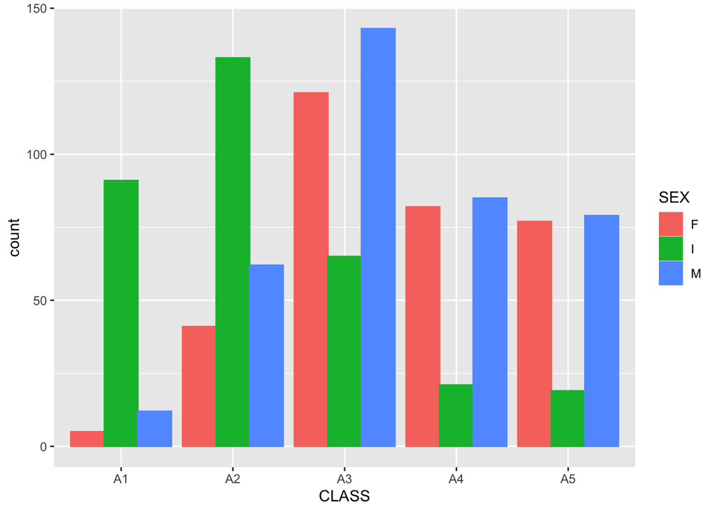

**Essay Question (2 points): Discuss the sex distribution of abalones. What stands out about the distribution of abalones by CLASS?**

*Answer: Close to 32% of the data points are in class A3, whereas the other 68% are spread accross the classes. Infants (non-gendered) are more concentrated in A1 and A2, whereas Males and Femals are more concentrated in A3 & A5. This can suggest one of two things. As infants age, abalones can change their class. Or, that there have been ecological changes that infant abalones are no longer being born in classes A3, A4 & A5. But, are now being born in A1 & A2.*

(1)(c) (1 point) Select a simple random sample of 200 observations from “mydata” and identify this sample as “work.” Use *set.seed(123)* prior to drawing this sample. Do not change the number 123. Note that *sample()* “takes a sample of the specified size from the elements of x.” We cannot sample directly from “mydata.” Instead, we need to sample from the integers, 1 to 1036, representing the rows of “mydata.” Then, select those rows from the data frame (Kabacoff Section 4.10.5 page 87).

Using “work”, construct a scatterplot matrix of variables 2-6 with *plot(work[, 2:6])* (these are the continuous variables excluding VOLUME and RATIO). The sample “work” will not be used in the remainder of the assignment.

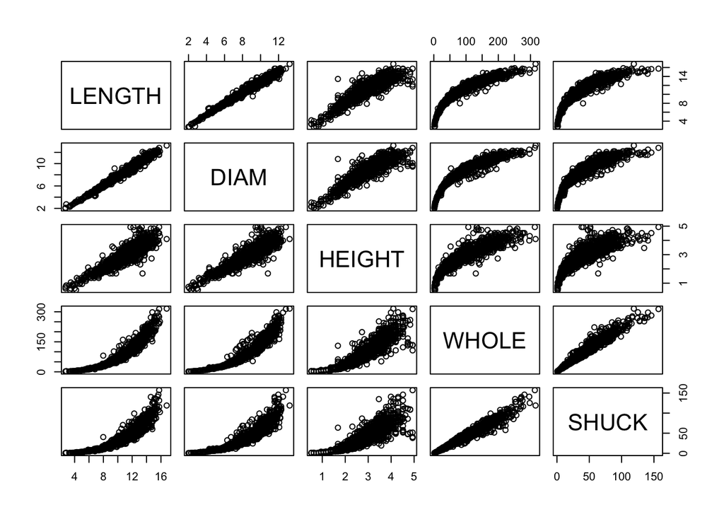

*##### Section 2: (5 points) Summarizing the data using graphics.*

(2)(a) (1 point) Use “mydata” to plot WHOLE versus VOLUME. Color code data points by CLASS.

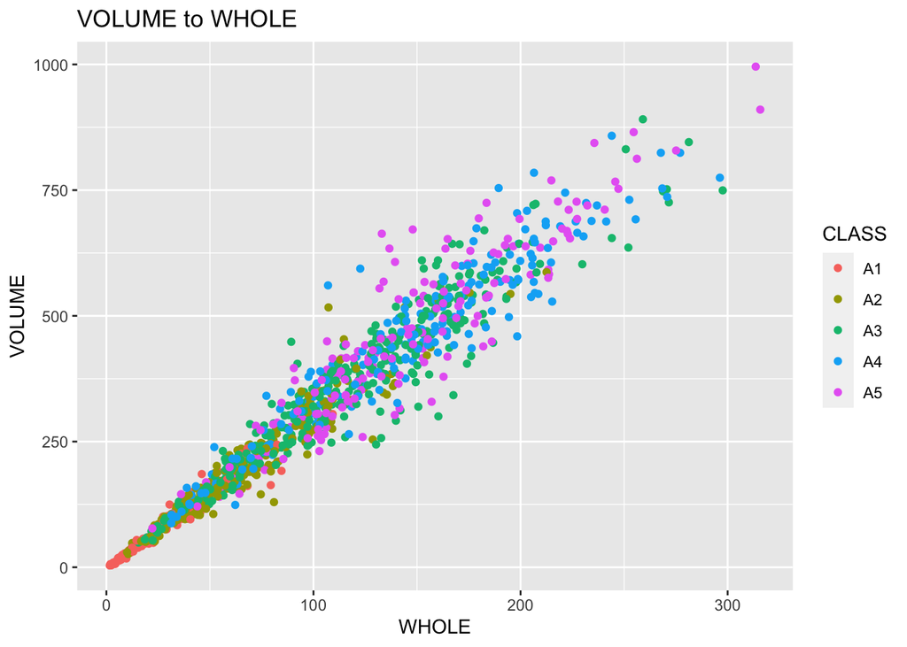

(2)(b) (2 points) Use “mydata” to plot SHUCK versus WHOLE with WHOLE on the horizontal axis. Color code data points by CLASS. As an aid to interpretation, determine the maximum value of the ratio of SHUCK to WHOLE. Add to the chart a straight line with zero intercept using this maximum value as the slope of the line. If you are using the ‘base R’ *plot()* function, you may use *abline()* to add this line to the plot. Use *help(abline)* in R to determine the coding for the slope and intercept arguments in the functions. If you are using ggplot2 for visualizations, *geom_abline()* should be used.

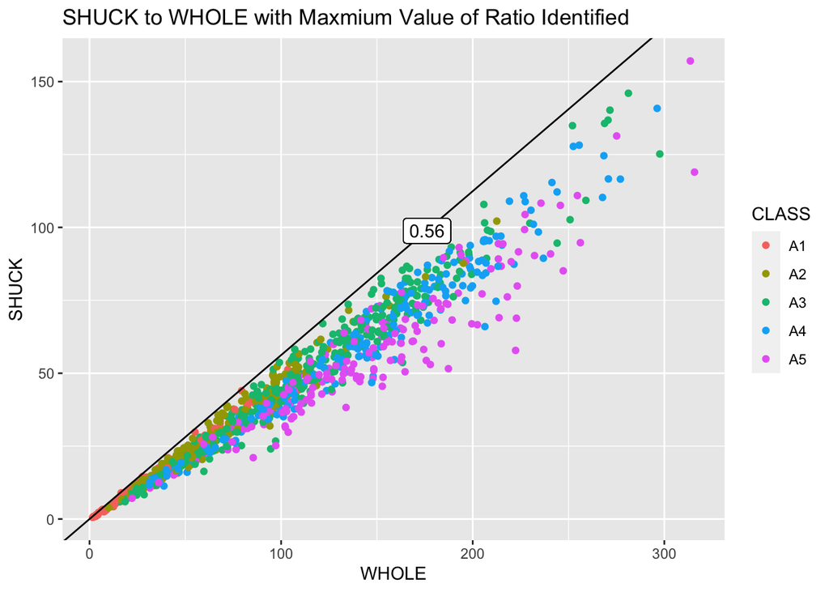

**Essay Question (2 points): How does the variability in this plot differ from the plot in (a)? Compare the two displays. Keep in mind that SHUCK is a part of WHOLE. Consider the location of the different age classes.**

*Answer: There is less spread and variability in SHUCK to WHOLE versus the variability in VOLUME to WHOLE. Per the prompt, shucking is the amount of meat that is extracted from an abalone, and the volume is the entire space taken. The variability in VOLUME to WHOLE could suggest that the shell of the abalones don’t weigh as much. There could be abalones with larger shells and volumes, but not enough whole weight. Conversely, there could be abalones with larger whole weight and shucked meat, with smaller shells. It also means that while shucking abalones, concerned parties are more concerned with the weight of the abalone rather than volume and size. Looking at class, since A1 and A2 house mostly infants, we can see that fewer meat is shucked given that concerned parties are trying to make sure the species is able to reproduce and sustain itself. Whereas, A3, A4 and A5 house grown males and females and have greater meat shucked. We can also see that infants have lower volums and whole weight in comparison to their gendered counterparts.*

*### Section 3: (8 points) Getting insights about the data using graphs.*

(3)(a) (2 points) Use “mydata” to create a multi-figured plot with histograms, boxplots and Q-Q plots of RATIO differentiated by sex. This can be done using *par(mfrow = c(3,3))* and base R or *grid.arrange()* and ggplot2. The first row would show the histograms, the second row the boxplots and the third row the Q-Q plots. Be sure these displays are legible.

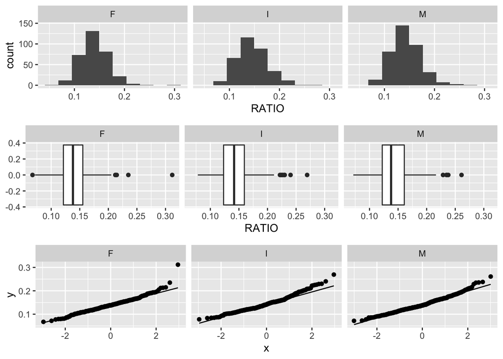

**Essay Question (2 points): Compare the displays. How do the distributions compare to normality? Take into account the criteria discussed in the sync sessions to evaluate non-normality.**

*Answer: All three illustrations depict outliers. However, looking at the first illustration only, all three segments seem to suggest that the data for Female and Infants is somewhat positively skewed, whereas the data for Males is closer to Normality. However, looking at the second illustration, where we’re observing quantiles and any visual illusions the histograms might create are taken away, we observe that the data is closer to normality for Females and Infants, whereas there may be some positive skewness for Males. The qqplots would suggest that the data is normal for Females and Males whereas there’s some deviation from the straight line for Infants. However, the points for Infants still follow a mostly straight line and do not vehemently suggest non-normality. In conclusion, all three segments suggest that the RATIO for all three sexes is closer to normality than non-normality.*

(3)(b) (2 points) The boxplots in (3)(a) indicate that there are outlying RATIOs for each sex. *boxplot.stats()* can be used to identify outlying values of a vector. Present the abalones with these outlying RATIO values along with their associated variables in “mydata”. Display the observations by passing a data frame to the kable() function. Basically, we want to output those rows of “mydata” with an outlying RATIO, but we want to determine outliers looking separately at infants, females and males.

|  | SEX | LENGTH | DIAM | HEIGHT | WHOLE | SHUCK | RINGS | CLASS | VOLUME | RATIO | NEW_RATIO |
| --- | --- | --- | --- | --- | --- | --- | --- | --- | --- | --- | --- |
| 3 | I | 10.080 | 7.350 | 2.205 | 79.37500 | 44.00000 | 6 | A1 | 163.364040 | 0.2693371 | 0.5543307 |
| 37 | I | 4.305 | 3.255 | 0.945 | 6.18750 | 2.93750 | 3 | A1 | 13.242072 | 0.2218308 | 0.4747475 |
| 42 | I | 2.835 | 2.730 | 0.840 | 3.62500 | 1.56250 | 4 | A1 | 6.501222 | 0.2403394 | 0.4310345 |
| 58 | I | 6.720 | 4.305 | 1.680 | 22.62500 | 11.00000 | 5 | A1 | 48.601728 | 0.2263294 | 0.4861878 |
| 67 | I | 5.040 | 3.675 | 0.945 | 9.65625 | 3.93750 | 5 | A1 | 17.503290 | 0.2249577 | 0.4077670 |
| 89 | I | 3.360 | 2.310 | 0.525 | 2.43750 | 0.93750 | 4 | A1 | 4.074840 | 0.2300704 | 0.3846154 |
| 105 | I | 6.930 | 4.725 | 1.575 | 23.37500 | 11.81250 | 7 | A2 | 51.572194 | 0.2290478 | 0.5053476 |
| 200 | I | 9.135 | 6.300 | 2.520 | 74.56250 | 32.37500 | 8 | A2 | 145.027260 | 0.2232339 | 0.4341995 |
| 350 | F | 7.980 | 6.720 | 2.415 | 80.93750 | 40.37500 | 7 | A2 | 129.505824 | 0.3117620 | 0.4988417 |
| 420 | F | 11.550 | 7.980 | 3.465 | 150.62500 | 68.55375 | 10 | A3 | 319.365585 | 0.2146560 | 0.4551286 |
| 458 | F | 11.445 | 8.085 | 3.150 | 139.81250 | 68.49062 | 9 | A3 | 291.478399 | 0.2349767 | 0.4898748 |
| 586 | F | 12.180 | 9.450 | 4.935 | 133.87500 | 38.25000 | 14 | A5 | 568.023435 | 0.0673388 | 0.2857143 |
| 746 | M | 13.440 | 10.815 | 1.680 | 130.25000 | 63.73125 | 10 | A3 | 244.194048 | 0.2609861 | 0.4892994 |
| 754 | M | 10.500 | 7.770 | 3.150 | 132.68750 | 61.13250 | 9 | A3 | 256.992750 | 0.2378764 | 0.4607254 |
| 803 | M | 10.710 | 8.610 | 3.255 | 160.31250 | 70.41375 | 9 | A3 | 300.153640 | 0.2345924 | 0.4392281 |
| 810 | M | 12.285 | 9.870 | 3.465 | 176.12500 | 99.00000 | 10 | A3 | 420.141472 | 0.2356349 | 0.5621008 |
| 852 | M | 11.550 | 8.820 | 3.360 | 167.56250 | 78.27187 | 10 | A3 | 342.286560 | 0.2286735 | 0.4671205 |
| 870 | M | 11.445 | 8.610 | 2.520 | 99.12500 | 53.70750 | 9 | A3 | 248.324454 | 0.2162795 | 0.5418159 |

**Essay Question (2 points): What are your observations regarding the results in (3)(b)?**

*Answer: 4 out of every 9 outlier is an Infant. These Infants are bigger in Volume (overall size) than the amount of shucked meat. Whereas the remaining Females and Males are bigger in Volume (overall size) than the amount of shucked meat in them.It could mean that they have heavier shells as the overall weight is still high for these outliers - the weight of the shuckable meat is low in these respective Males and Females.*

*### Section 4: (8 points) Getting insights about possible predictors.*

(4)(a) (3 points) With “mydata,” display side-by-side boxplots for VOLUME and WHOLE, each differentiated by CLASS There should be five boxes for VOLUME and five for WHOLE. Also, display side-by-side scatterplots: VOLUME and WHOLE versus RINGS. Present these four figures in one graphic: the boxplots in one row and the scatterplots in a second row. Base R or ggplot2 may be used.

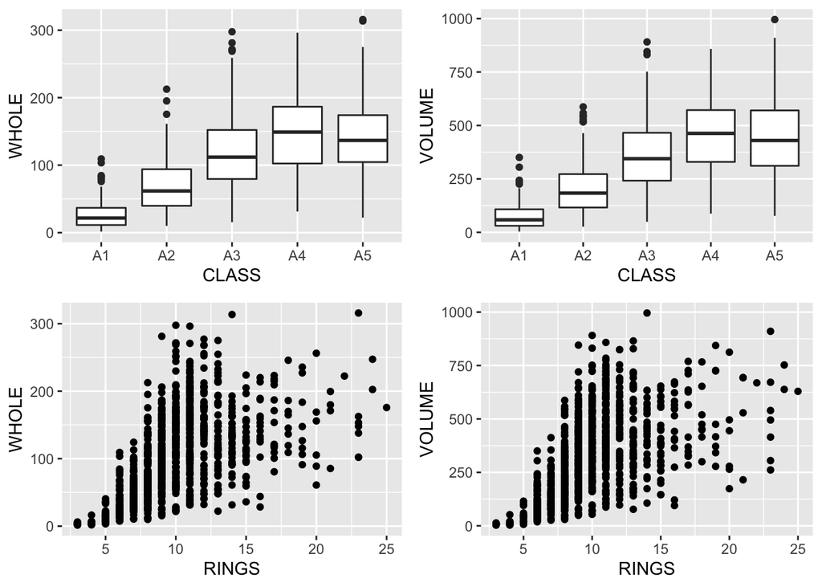

**Essay Question (5 points) How well do you think these variables would perform as predictors of age? Explain.**

*Answer: Referring to the scatterplots, we can see that as Rings increase, the Volume and Whole weight tend to increase (similarly with CLASS and WHOLE/VOLUME), which does indicate some linear relationship bewteen the two. However, we can see from the previous charts that Volume and Whole have a strong correlation with one another. Therefore, adding both to the linear regression model would violate the assumption of the predictors being independent. We can see that as the Volume increases, the Whole weight also increases - alluding to dependency between the two. Adding one of Whole Weight and Volume as a predictor would be useful. Referring to the boxplots, we see similar behavior between the Volume variable and the Whole variable. However, we also observe that Class does have an impact on the Whole and Volume Variable. Therefore, whereas it would be useful to add Class as a predictor, it would be even more useful to model the interaction between Class and either one of Whole or Volume. I would also further explore the interaction between Whole/Volume and Sex given that we know that A3, A4 and A5 mostly house males and females. Whereas, A1 and A2 house infants.*

*### Section 5: (12 points) Getting insights regarding different groups in the data.*

(5)(a) (2 points) Use *aggregate()* with “mydata” to compute the mean values of VOLUME, SHUCK and RATIO for each combination of SEX and CLASS. Then, using *matrix()*, create matrices of the mean values. Using the “dimnames” argument within *matrix()* or the *rownames()* and *colnames()* functions on the matrices, label the rows by SEX and columns by CLASS. Present the three matrices (Kabacoff Section 5.6.2, p. 110-111). The *kable()* function is useful for this purpose. You do not need to be concerned with the number of digits presented.

```
## $VOLUME
##       A1     A2     A3     A4     A5
## F 255.30 276.86 412.61 498.05 486.15
## I  66.52 160.32 270.74 316.41 318.69
## M 103.72 245.39 358.12 442.62 440.21
##
## $SHUCK
##      A1    A2    A3    A4    A5
## F 38.90 42.50 59.69 69.05 59.17
## I 10.11 23.41 37.18 39.85 36.47
## M 16.40 38.34 52.97 61.43 55.03
##
## $RATIO
##      A1    A2    A3    A4    A5
## F 0.155 0.155 0.145 0.138 0.123
## I 0.157 0.148 0.137 0.124 0.117
## M 0.151 0.156 0.146 0.136 0.126
```

(5)(b) (3 points) Present three graphs. Each graph should include three lines, one for each sex. The first should show mean RATIO versus CLASS; the second, mean VOLUME versus CLASS; the third, mean SHUCK versus CLASS. This may be done with the ‘base R’ *interaction.plot()* function or with ggplot2 using *grid.arrange()*.

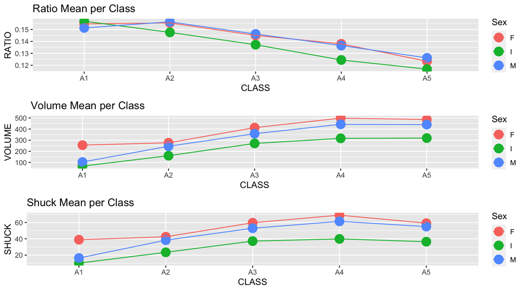

**Essay Question (2 points): What questions do these plots raise? Consider aging and sex differences.**

*Answer: It appears that despite the fact that most Infants are housed under A1 and A2 (younger in Age), there are Infants with significant Volume and Shuck in later classes such as A4 and A5. This tells us that there are some abalones who have been classified as Infants that are not really Infants in age. And though they might age, they never genderize into either Male or Female. Either that, or there is some miscategorization of these records - some Male & Females were recorded as Infants. Assuming the data is accurate, this poses several questions for the survival of this species. It would be helpful to know whether this non-genderization is a trend due to ecologicial reasons (maybe the abalones are under stress), or it’s very common for a minute segment of abalones to not genderize. Furthermore, if it’s a trend, then at what rate is non-genderization increasing? If non-genderization is increasing, then that could severely hamper abalone reproduction and the survival of this species.*

5(c) (3 points) Present four boxplots using *par(mfrow = c(2, 2)* or *grid.arrange()*. The first line should show VOLUME by RINGS for the infants and, separately, for the adult; factor levels “M” and “F,” combined. The second line should show WHOLE by RINGS for the infants and, separately, for the adults. Since the data are sparse beyond 15 rings, limit the displays to less than 16 rings. One way to accomplish this is to generate a new data set using subset() to select RINGS < 16. Use ylim = c(0, 1100) for VOLUME and ylim = c(0, 400) for WHOLE. If you wish to reorder the displays for presentation purposes or use ggplot2 go ahead.

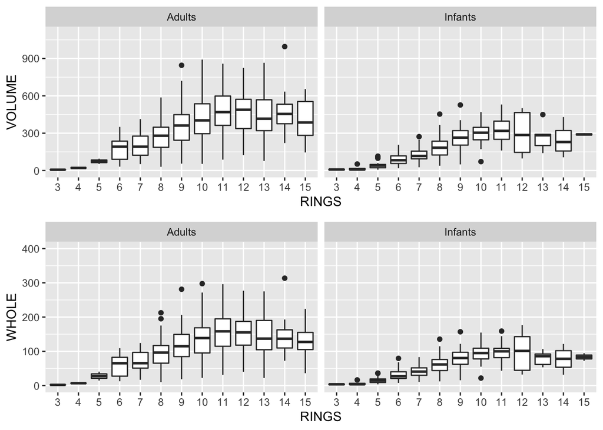

**Essay Question (2 points): What do these displays suggest about abalone growth? Also, compare the infant and adult displays. What differences stand out?**

*Answer: In general, the displays suggest that as the number of rings increases the Volume (size) of the abalones, and the overall Whole Weight also increases. However, we do see some contrarion datapoints to the generalization mentioned. For instance, in the visual comparing Whole Weight and Rings, we observe that the median Whole Weight for Rings 13 to 15 decreases from Rings 11 and 12.We see similar fluctuation in comparing Volume to Rings. The movement would suggest that abalones don’t really grow in volume or weight beyond with beyond a certain amount of Rings. We see similar movement for Infants. However, understandably, the median volume and weight for Infants is alot smaller than the Adults. Barring the data in Ring 12, the spread of volume and weight in the other rings isn’t that large.*

*### Section 6: (11 points) Conclusions from the Exploratory Data Analysis (EDA).*

**Conclusions**

**Essay Question 1) (5 points) Based solely on these data, what are plausible statistical reasons that explain the failure of the original study? Consider to what extent physical measurements may be used for age prediction.**

*Answer: The original study was aimed to determine the age of the abalones based on measuring physical characteristics. It would seem that the assumption was that the more voluminous and heavy the abalones would be, the older they would be and therefore have more rings. Knowing the age of the abalones was also necessary in helping harvesters only fish for mature abalones as immature abalones would be left for reproduction and sustenance of the species. However, the data available suggests that volume and weight are not perfect predictors of maturity. The data shows that there are immature abalones, assuming their categorization is correct, that have more rings, have greater volume and are heavy in weight. Harvesters would have a hard time determining the maturity of the abalones based on number of rings, weight, and volume alone. More data would be required to determine why some immature (if the miscategorization hasn’t taken place) abalones though grow in large sizes and obtain more rings, are not genderizing.*

**Essay Question 2) (3 points) Do not refer to the abalone data or study. If you were presented with an overall histogram and summary statistics from a sample of some population or phenomenon and no other information, what questions might you ask before accepting them as representative of the sampled population or phenomenon?**

*Answer: The first question to ask would be would sampling methodology was deployed; whether probability based sampling or non-probability based sampling. If it was probability based sampling, it would be helpful to know what methodology was deployed to sample the population. For instance, if stratified sampling was used - a check would need to be conducted to make sure that the there is homogeneity within the groups and heterogeneity in between the groups. Additionally, we would also check for whether the approach was meant to be proportionate vs disproportionate. All the above would help us answer whether the frame (the sample that is representative of the population)is over-registered or under-registered. To verify that the sampling is representative of the original population, we would look at the sample mean, which is the best estimate of the population mean in our case. On top of which, the associated confidence interval that we would like to have for the calculated mean. Then we would look at the standard error of the sample mean - the higher the error, the less ucnertain would we be that our sample mean is the best approximation of the population mean, and the more certain we would be that the sample is not representative of the population.*

**Essay Question 3) (3 points) Do not refer to the abalone data or study. What do you see as difficulties analyzing data derived from observational studies? Can causality be determined? What might be learned from such studies?**

*Answer: Observational data, without any objective of research, may have variables that have mutli-collinearity; can easily fail to capture spurious relationships when comparing cause and effect and therefore ignoring true drivers,and is restrictive in explaining the root causes of a phenomenon. Observational studies can sometimes be useful in determining patterns - for instance is an observation study is done of observing social media posts within the summer month, we may see that more posts might happen during the summer versus other months. But, it won’t tell us why we’re observing that behavior even though there may be a few reasons we can think of. It’s difficult to determine causality as observational datasets can often ignore spurious relationships and do not capture the variables needed to explain cause and effect.*